# Linear Regression Analysis – Can LOS be explained by admission stage, age, and race?

Steph Reynolds (Stephanie.Reynolds@ucsf.edu)

Jan 21, 2022 12:13 PM

# 1 Background

## 1.1 Project

MINDSCAPE: Modeling of infectious network dynamics for surveillance, control and prevention enhancement

## 1.2 Description

This file imports `dm_stg_unique_pt_11.08.21.csv` and generates a linear regression model to evaluate the extent to which length of stay can be explained by admission stage, age, and race. Model parameters include:

- `LOS` -> Length of stay that patient was hospitalized (in days)
  - 4 different regression models where `LOS` is: (1) not transformed, (2) log-transformed, (3) square root-transformed, and (4) cube root-transformed
- `stage_adm_cat` -> Admission stage categorized into moderate (stages 4-5) and severe (stages 6+)
- `age` -> Age of patient at admission
- `race` -> Race category (Black, White, Asian, Haw/PI, Other, Unknown) **Still unsure how to treat `race`**

# 2 Load required packages

# 3 Import and preview data

```r
df <- read_csv("/Users/sreynolds2/Documents/GitHub/MS-Covid_Staging/data/dm_stg_unique_pt_11.08.21.csv")

head(df, n=10)
```

```
## # A tibble: 10 × 16
##    ID           age sex   zip   race  ethnicity smoking   BMI death DOD      LOS
##    <chr>      <dbl> <chr> <chr> <chr> <chr>     <chr>   <dbl> <chr> <date> <dbl>
##  1 0055f0c4-…    53 Male  95382 Other Hispanic… Not Cu…  31.6 No    NA         9
##  2 00a80297-…    57 Male  94939 Whit… Not Hisp… Curren…  42.0 No    NA         8
##  3 01abe61d-…    51 Male  93722 Whit… Hispanic… Not Cu…  28.6 No    NA         9
##  4 01b4c414-…    67 Male  94901 Whit… Hispanic… Not Cu…  27.2 No    NA         8
##  5 01ef2f14-…    66 Fema… 9455… Whit… Not Hisp… Not Cu…  28.2 No    NA         2
##  6 020b86bb-…    83 Fema… 94110 Other Hispanic… Not Cu…  22.4 No    NA        13
##  7 0219f9cf-…    55 Fema… 94606 Asian Not Hisp… Not Cu…  34.1 No    NA        12
##  8 027bf945-…    39 Male  94110 Other Not Hisp… Not Cu…  35.8 No    NA         2
##  9 02ca48f6-…    52 Fema… 96002 Whit… Not Hisp… Not Cu…  30.1 No    NA         4
## 10 02cc5218-…    49 Fema… 95205 Other Hispanic… Not Cu…  30.8 No    NA         6
## # … with 5 more variables: max_stage <dbl>, date_adm <date>, date_disc <date>,
## #   stage_adm <dbl>, stage_disc <dbl>
```

# 4 Convert variables to factor type and create dataset with only relevant parameters

```r
# Assign list of variables to be converted to factor type
vars_fct <- c("sex", "race", "ethnicity", "smoking", "death", "max_stage", "stage_adm", "stage_disc")

# Convert these variables to factor type
df <- df %>%
  mutate_at(vars_fct, factor)

# Categorize admission stage into 'moderate' and 'severe'
# Create dataset with only relevant parameters and assign to `regdf`
regdf <- df %>%
  mutate(stage_adm_cat = ifelse(stage_adm %in% 4:5, "Moderate", "Severe")) %>%
  select(ID, age, race, LOS, stage_adm, stage_adm_cat)
```

# 5 Create dataset that excludes LOS outliers

**ASK TRAVIS WHETHER TO RUN REGRESSIONS WITH FULL DATASET OR WITHOUT LOS OUTLIERS** **CAN DELETE THIS SECTION IF NOT USING DATASET WITHOUT OUTLIERS**

```r
# Identify outliers using boxplot method; save to vector
outliers <- boxplot(regdf$LOS)$out

# Exclude outliers from dataset
regdf_no_outliers <- regdf[-which(regdf$LOS %in% outliers), ]
```

# 6 Fit linear regression model m1: LOS ~ stage_adm_cat + poly(age, 2)

Where outcome (LOS) is not transformed

```r
# Fit model
m1 <- lm(LOS ~ stage_adm_cat + poly(age, 2) + race, data = regdf)

# Summarize regression output
summary(m1)
```

```
##
## Call:
## lm(formula = LOS ~ stage_adm_cat + poly(age, 2) + race, data = regdf)
##
## Residuals:
##     Min      1Q  Median      3Q     Max
## -24.989  -7.751  -3.942   1.586 216.156
##
## Coefficients:
##                                               Estimate Std. Error t value
## (Intercept)                                    10.8421     1.2209   8.880
## stage_adm_catSevere                            11.7763     1.3855   8.499
## poly(age, 2)1                                  38.4592    18.7257   2.054
## poly(age, 2)2                                 -70.1039    17.6905  -3.963
## raceBlack or African American                  -0.6341     2.0668  -0.307
## raceNative Hawaiian or Other Pacific Islander   4.8521     4.3269   1.121
## raceOther                                       2.4752     1.5900   1.557
## raceUnknown                                    -4.0168     3.3264  -1.208
## raceWhite or Caucasian                         -1.3942     1.4841  -0.939
##                                               Pr(>|t|)
## (Intercept)                                    < 2e-16 ***
## stage_adm_catSevere                            < 2e-16 ***
## poly(age, 2)1                                   0.0402 *
## poly(age, 2)2                                 7.88e-05 ***
## raceBlack or African American                   0.7591
## raceNative Hawaiian or Other Pacific Islander   0.2624
## raceOther                                       0.1198
## raceUnknown                                     0.2275
## raceWhite or Caucasian                          0.3477
## ---
## Signif. codes:  0 '***' 0.001 '**' 0.01 '*' 0.05 '.' 0.1 ' ' 1
##
## Residual standard error: 17.61 on 1108 degrees of freedom
## Multiple R-squared:  0.09027,    Adjusted R-squared:  0.0837
## F-statistic: 13.74 on 8 and 1108 DF,  p-value: < 2.2e-16
```

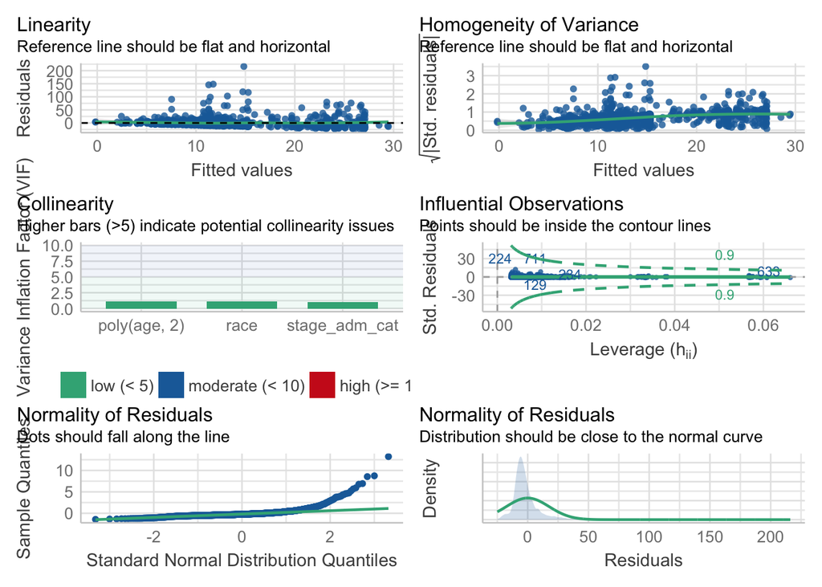

```r
# Check assumptions for `m1`
check_model(m1)
```

```r
# Check performance for `m1`
model_performance(m1)
```

```
## # Indices of model performance
##
## AIC      |      BIC |    R2 | R2 (adj.) |   RMSE |  Sigma
## ---------------------------------------------------------
## 9588.747 | 9638.931 | 0.090 |     0.084 | 17.537 | 17.608
```

# 7 Fit linear regression model m2: log(LOS) ~ stage_adm_cat + poly(age, 2)

Where outcome (LOS) is transformed on log scale

```r
# Fit model
m2 <- lm(log(LOS) ~ stage_adm_cat + poly(age, 2) + race, data = regdf)

# Summarize regression output
summary(m2)
```

```
##
## Call:
## lm(formula = log(LOS) ~ stage_adm_cat + poly(age, 2) + race,
##     data = regdf)
##
## Residuals:
##     Min      1Q  Median      3Q     Max
## -2.6964 -0.5633 -0.0250  0.5414  3.3589
##
## Coefficients:
##                                               Estimate Std. Error t value
## (Intercept)                                    1.95540    0.06203  31.525
## stage_adm_catSevere                            0.75532    0.07039  10.730
## poly(age, 2)1                                  5.00426    0.95134   5.260
## poly(age, 2)2                                 -3.85823    0.89875  -4.293
## raceBlack or African American                 -0.06128    0.10500  -0.584
## raceNative Hawaiian or Other Pacific Islander  0.43910    0.21982   1.998
## raceOther                                      0.06454    0.08078   0.799
## raceUnknown                                   -0.16578    0.16899  -0.981
## raceWhite or Caucasian                        -0.11973    0.07540  -1.588
##                                               Pr(>|t|)
## (Intercept)                                    < 2e-16 ***
## stage_adm_catSevere                            < 2e-16 ***
## poly(age, 2)1                                 1.73e-07 ***
## poly(age, 2)2                                 1.92e-05 ***
## raceBlack or African American                    0.560
## raceNative Hawaiian or Other Pacific Islander    0.046 *
## raceOther                                        0.425
## raceUnknown                                      0.327
## raceWhite or Caucasian                           0.113
## ---
## Signif. codes:  0 '***' 0.001 '**' 0.01 '*' 0.05 '.' 0.1 ' ' 1
##
## Residual standard error: 0.8945 on 1108 degrees of freedom
## Multiple R-squared:  0.1453, Adjusted R-squared:  0.1392
## F-statistic: 23.55 on 8 and 1108 DF,  p-value: < 2.2e-16
```

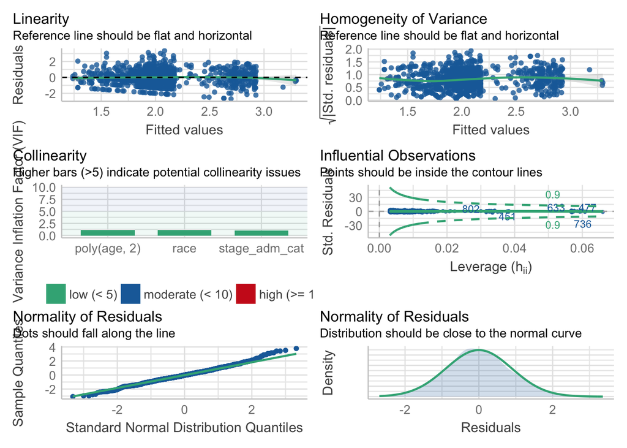

```r
# Check assumptions for `m2`
check_model(m2)
```

```r
# Check performance for `m2`
model_performance(m2)
```

```
## # Indices of model performance
##
## AIC      |      BIC |    R2 | R2 (adj.) |  RMSE | Sigma
## -------------------------------------------------------
## 2931.922 | 2982.106 | 0.145 |     0.139 | 0.891 | 0.895
```

# 8 Fit linear regression model m3: sqrt(LOS) ~ stage_adm_cat + poly(age, 2)

Where outcome (LOS) is transformed on square root scale

```r
# Fit model
m3 <- lm(sqrt(LOS) ~ stage_adm_cat + poly(age, 2) + race, data = regdf)

# Summarize regression output
summary(m3)
```

```
##
## Call:
## lm(formula = sqrt(LOS) ~ stage_adm_cat + poly(age, 2) + race,
##     data = regdf)
##
## Residuals:
##     Min      1Q  Median      3Q     Max
## -3.3370 -0.9728 -0.3254  0.5706 11.9403
##
## Coefficients:
##                                               Estimate Std. Error t value
## (Intercept)                                     2.9434     0.1134  25.964
## stage_adm_catSevere                             1.3920     0.1287  10.820
## poly(age, 2)1                                   6.2801     1.7388   3.612
## poly(age, 2)2                                  -7.0779     1.6427  -4.309
## raceBlack or African American                  -0.1000     0.1919  -0.521
## raceNative Hawaiian or Other Pacific Islander   0.6952     0.4018   1.730
## raceOther                                       0.1778     0.1476   1.204
## raceUnknown                                    -0.3879     0.3089  -1.256
## raceWhite or Caucasian                         -0.1880     0.1378  -1.364
##                                               Pr(>|t|)
## (Intercept)                                    < 2e-16 ***
## stage_adm_catSevere                            < 2e-16 ***
## poly(age, 2)1                                 0.000318 ***
## poly(age, 2)2                                 1.79e-05 ***
## raceBlack or African American                 0.602357
## raceNative Hawaiian or Other Pacific Islander 0.083854 .
## raceOther                                     0.228802
## raceUnknown                                   0.209377
## raceWhite or Caucasian                        0.172841
## ---
## Signif. codes:  0 '***' 0.001 '**' 0.01 '*' 0.05 '.' 0.1 ' ' 1
##
## Residual standard error: 1.635 on 1108 degrees of freedom
## Multiple R-squared:  0.1355, Adjusted R-squared:  0.1292
## F-statistic:  21.7 on 8 and 1108 DF,  p-value: < 2.2e-16
```

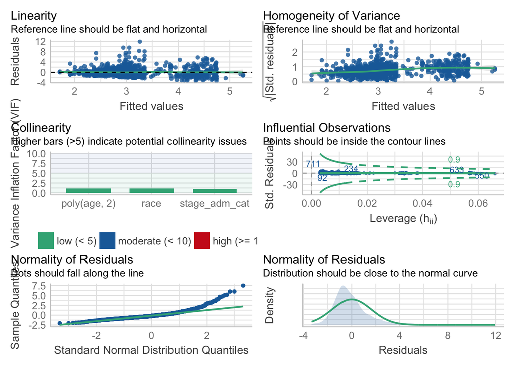

```r
# Check assumptions for `m3`
check_model(m3)
```

```r
# Check performance for `m3`
model_performance(m3)
```

```
## # Indices of model performance
##
## AIC      |      BIC |    R2 | R2 (adj.) |  RMSE | Sigma
## -------------------------------------------------------
## 4279.183 | 4329.367 | 0.135 |     0.129 | 1.628 | 1.635
```

# 9 Fit linear regression model m4: (LOS^(1/3)) ~ stage_adm_cat + poly(age, 2)

Where outcome (LOS) is transformed on cube root scale

```r
# Fit model
m4 <- lm(LOS^(1/3) ~ stage_adm_cat + poly(age, 2) + race, data = regdf)

# Summarize regression output
summary(m4)
```

```
##
## Call:
## lm(formula = LOS^(1/3) ~ stage_adm_cat + poly(age, 2) + race,
##     data = regdf)
##
## Residuals:
##     Min      1Q  Median      3Q     Max
## -1.5771 -0.4277 -0.1017  0.3048  4.0098
##
## Coefficients:
##                                               Estimate Std. Error t value
## (Intercept)                                    2.00637    0.04693  42.757
## stage_adm_catSevere                            0.59108    0.05325  11.100
## poly(age, 2)1                                  3.02355    0.71972   4.201
## poly(age, 2)2                                 -2.95248    0.67993  -4.342
## raceBlack or African American                 -0.04431    0.07944  -0.558
## raceNative Hawaiian or Other Pacific Islander  0.31142    0.16630   1.873
## raceOther                                      0.06523    0.06111   1.067
## raceUnknown                                   -0.15268    0.12785  -1.194
## raceWhite or Caucasian                        -0.08379    0.05704  -1.469
##                                               Pr(>|t|)
## (Intercept)                                    < 2e-16 ***
## stage_adm_catSevere                            < 2e-16 ***
## poly(age, 2)1                                 2.87e-05 ***
## poly(age, 2)2                                 1.54e-05 ***
## raceBlack or African American                   0.5771
## raceNative Hawaiian or Other Pacific Islander   0.0614 .
## raceOther                                       0.2861
## raceUnknown                                     0.2327
## raceWhite or Caucasian                          0.1421
## ---
## Signif. codes:  0 '***' 0.001 '**' 0.01 '*' 0.05 '.' 0.1 ' ' 1
##
## Residual standard error: 0.6768 on 1108 degrees of freedom
## Multiple R-squared:  0.1439, Adjusted R-squared:  0.1377
## F-statistic: 23.28 on 8 and 1108 DF,  p-value: < 2.2e-16
```

```r
# Check assumptions for `m2`
# check_model(m4) -- GENERATES ERROR MESSAGE

# Check performance for `m2`
model_performance(m4)
```

```
## # Indices of model performance
##
## AIC      |      BIC |    R2 | R2 (adj.) |  RMSE | Sigma
## -------------------------------------------------------
## 2308.600 | 2358.784 | 0.144 |     0.138 | 0.674 | 0.677
```

# 10 Visualize most important features for `m1`

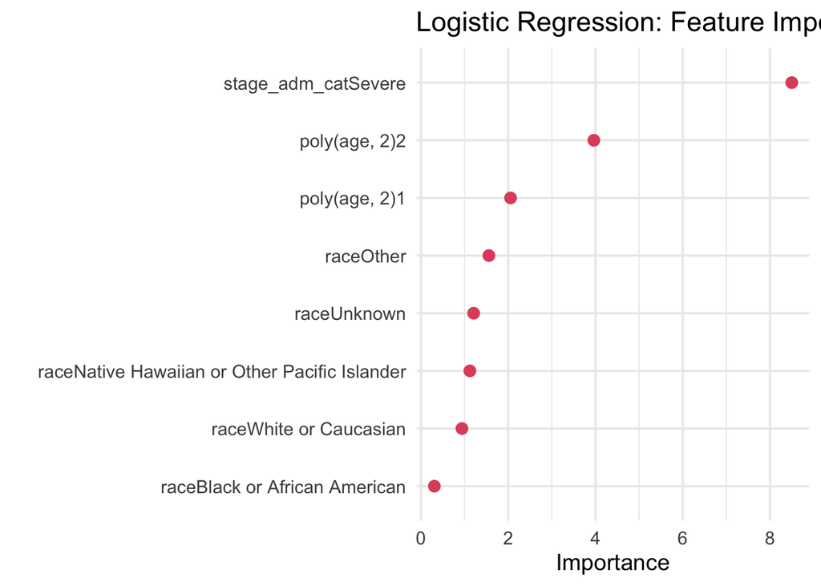

```r
m1 %>% vip(num_features = 15,
           geom = "point",
           aes = list(size = 3, color = '18bc9c')) +
  theme_minimal(base_size = 14) +
  labs(title = "Logistic Regression: Feature Importance")
```

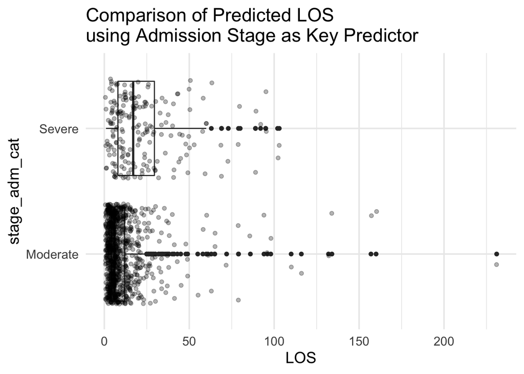

```r
  # Feature with highest importance are: stage_adm_cat == SEVERE

regdf %>% ggplot(aes(LOS, stage_adm_cat)) +
  geom_boxplot() +
  geom_jitter(alpha = 0.3) +
  theme_minimal(base_size = 15) +
  labs(title = "Comparison of Predicted LOS\nusing Admission Stage as Key Predictor")
```

# 11 Visualize most important features for m2

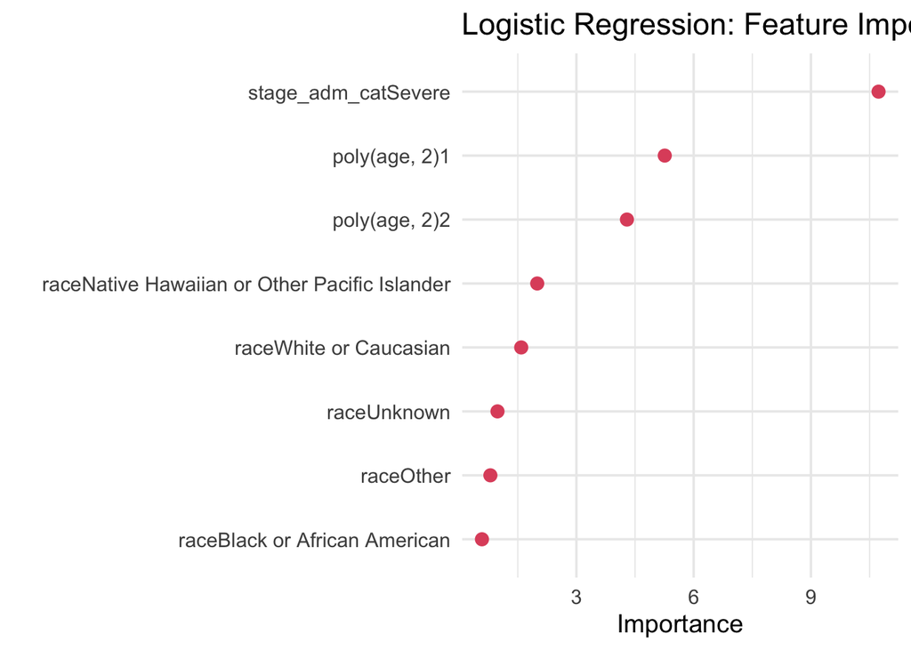

```r
m2 %>% vip(num_features = 15,
           geom = "point",
           aes = list(size = 3, color = '18bc9c')) +
  theme_minimal(base_size = 14) +
  labs(title = "Logistic Regression: Feature Importance")
```

```r
  # Feature with highest importance are: stage_adm_cat == SEVERE
```

# 12 Visualize most important features for m3

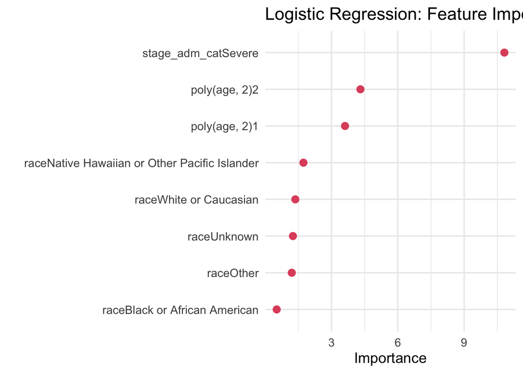

```r
m3 %>% vip(num_features = 15,
           geom = "point",
           aes = list(size = 3, color = '18bc9c')) +
  theme_minimal(base_size = 14) +
  labs(title = "Logistic Regression: Feature Importance")
```

```r
  # Feature with highest importance are: stage_adm_cat == SEVERE
```

# 13 Visualize most important features for m4

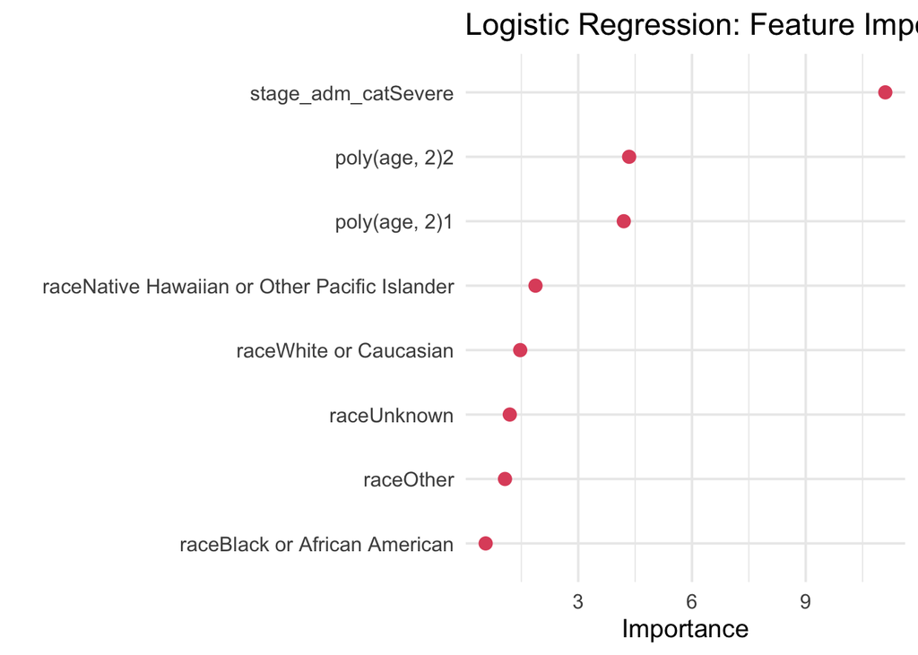

```r
m4 %>% vip(num_features = 15,
           geom = "point",
           aes = list(size = 3, color = '18bc9c')) +
  theme_minimal(base_size = 14) +
  labs(title = "Logistic Regression: Feature Importance")
```

```r
  # Feature with highest importance are: stage_adm_cat == SEVERE
```

# 14 End of Document